# Group Project 2

Nikolay Skryabin, Torsten Bjerling, Jeanine Holscher.

2022-05-28

## Background

The World Health Organization has recently employed a new data science initiative, *CSIT-165*, that uses data science to characterize pandemic diseases. *CSIT-165* disseminates data driven analyses to global decision makers.

*CSIT-165* is a conglomerate comprised of two fabricated entities: *World Health Organization (WHO)* and *U.S. Pandemic Response Team (USPRT)*. Your and your partner’s role is to play a data scientist from one of these two entities. Discuss with your partner to decide who will be part of *WHO* and *USPRT*.

## Data

> [2019 Novel Coronavirus COVID-19 (2019-nCoV) Data Repository by John Hopkins CSSE](https://github.com/CSSEGISandData/COVID-19/tree/master/csse_covid_19_data/csse_covid_19_time_series)

Data for 2019 Novel Coronavirus is operated by the John Hopkins University Center for Systems Science and Engineering (JHU CSSE). Data includes daily time series CSV summary tables, including confirmations and deaths. Country/region are countries/regions hat conform to World Health Organization (WHO). Lat and Long refer to coordinates references for the user. Date fields are stored in MM/DD/YYYY format.

#### GitHub Repository of the Project

> R-group-project-2

Download the data

```r
# URLs for the global confirmed and death cases files
URL_CONFIRMED_GLOBAL <- paste0("https://raw.githubusercontent.com/CSSEGISandData/",
                "COVID-19/master/csse_covid_19_data/csse_covid_19_time_series/",
                "time_series_covid19_confirmed_global.csv")


URL_DEATHS_GLOBAL <- paste0("https://raw.githubusercontent.com/CSSEGISandData/",
                "COVID-19/master/csse_covid_19_data/csse_covid_19_time_series/",
                "time_series_covid19_deaths_global.csv")

# URLs for the US confirmed and death cases files
URL_CONFIRMED_US <- paste0("https://raw.githubusercontent.com/CSSEGISandData/",
                "COVID-19/master/csse_covid_19_data/csse_covid_19_time_series/",
                "time_series_covid19_confirmed_US.csv")

URL_DEATHS_US <- paste0("https://raw.githubusercontent.com/CSSEGISandData/COVID-19/",
                     "master/csse_covid_19_data/csse_covid_19_time_series/",
                     "time_series_covid19_deaths_US.csv")

# Loads a file from URL and reads data from the file into data frame
getDataFrame <- function(url)
{
   # split the URL into list using "/" as delimiter
  url_list<-strsplit(url,split = "/")

  file_name <- sapply(url_list, tail, 1) # get the file name

  download.file(url, file_name) # download the file

  # create data frame from the file
  data_frame <- read.csv(file_name, stringsAsFactors = FALSE)

  data_frame # return it
}

# Get the data frames for the global deaths and confirmed cases
global_confirmed_df <- getDataFrame(URL_CONFIRMED_GLOBAL)
global_deaths_df <- getDataFrame(URL_DEATHS_GLOBAL)

# Get the data frames for the US deaths and confirmed cases
us_confirmed_df <- getDataFrame(URL_CONFIRMED_US)
us_deaths_df <- getDataFrame(URL_DEATHS_US)
```

## Project Objectives

### Objective 1

#### Global Map

```r
# Prepare data for the map:

# Calculates a sum of cases for each country
calculateSumCases <- function(df)
{
  result_sum <-na.omit(df) %>%                          # omit NAs
          filter((Lat & Long) != 0,
          !str_detect(Country.Region, 'Olympics'),
          !str_detect(Country.Region, 'Antarctica')) %>%# filter not countries
          rename(Last_Day = last_col()) %>%             # rename the last column
          group_by(Country.Region) %>%                  # aggregate the countries
          summarize("Sum"=sum(Last_Day,na.rm=T),
                    Lat.Mean=mean(Lat),
                    Long.Mean=mean(Long))%>%            # get a sum of cases
          select(Country.Region,Lat.Mean,Long.Mean,Sum) # get the countries data
}

# Get the global dataframes for the confirmed and death cases data sets
global_confirmed_sums <- calculateSumCases(global_confirmed_df) %>%
                          rename(Confirmed=Sum)
global_deaths_sums <- calculateSumCases(global_deaths_df) %>%
                      rename(Deaths=Sum)

# Add a column with the death cases to create a dataframe for all cases
global_all_sums <- global_confirmed_sums %>%
                    mutate(Deaths = global_deaths_sums$Deaths)

# Converts a column numbers to formatted strings
format_numbers<- function(a_column)
{
  # format as numeric(double)
  a_column <- format((as.numeric(a_column)),
                      big.mark = ",", nsmall = 1)

}

# The shades of blue, grey, and red for the circle markers
color_vec <- c("#0458AB","#36454F","#DC143C")

# Set palette for the markers using colorQuantile()
qpal_confirmed <- colorQuantile(color_vec, global_all_sums$Confirmed, n = 5)
qpal_deaths <- colorQuantile(color_vec, global_all_sums$Deaths, n = 5)

# Create a map for the confirmed and death cases
global_map <- leaflet(data = global_all_sums) %>%
  addProviderTiles("CartoDB.Positron") %>%
  setView(0, 0,  zoom = 1) %>%
  addCircleMarkers(lat = ~Lat.Mean, lng = ~Long.Mean,
                   popup = ~paste0("Confirmed: ",format_numbers(Confirmed)),
                   label = ~Country.Region,
                   color = ~qpal_confirmed(Confirmed), opacity = 0.8,
                   group = "Confirmed",stroke=FALSE) %>%
  addCircleMarkers(lat = ~Lat.Mean, lng = ~Long.Mean,
                   popup = ~paste0("Deaths: ",format_numbers(Deaths)),
                   label = ~Country.Region ,color = ~qpal_deaths(Deaths),
                   group = "Deaths",stroke=FALSE) %>%
  addLayersControl(overlayGroups = c("Confirmed","Deaths"),
                   options = layersControlOptions(collapsed = FALSE))

global_map
```

[interactive chart not shown]

### Objective 2

#### Narrowing Down Hot Spots

```r
# Prepare data for a table:

# Sorts a dataframe by the number of cases
getSortedByCases<- function(df)
{
  # subset a column with cases
  cases <- df[,4]
  # get result
  result <- df%>%
          arrange(desc(cases)) %>%          # sort the cases in desc order
          mutate_at(4,format_numbers)%>%    # format the cases
          select(Country=1, Counts=4)       # return the Columns
}

# Get sorted countries by the confirmed cases and add the Rank column
global_confirmed_rank <-getSortedByCases(global_confirmed_sums) %>%
mutate(Rank = row_number(), .before=Country)

# Get sorted countries by death cases
global_deaths_rank <-getSortedByCases(global_deaths_sums)

# Display 2 tables with the confirmations and deaths
kbl(list(global_confirmed_rank,global_deaths_rank),
  format = "html",align = "l") %>%
  kable_styling(fixed_thead = T)%>%
  kable_paper("striped") %>%
  add_header_above(c("Confirmations" = 1, "Deaths"=1)) %>%
  scroll_box(width = "100%", height = "300px")
```

Confirmations

Deaths

| Rank | Country | Counts |
| --- | --- | --- |
| 1 | US | 83,969,313.0 |
| 2 | India | 43,150,215.0 |
| 3 | Brazil | 30,921,145.0 |
| 4 | France | 29,631,816.0 |
| 5 | Germany | 26,240,639.0 |
| 6 | United Kingdom | 22,463,243.0 |
| 7 | Korea, South | 18,067,669.0 |
| 8 | Russia | 18,048,085.0 |
| 9 | Italy | 17,355,119.0 |
| 10 | Turkey | 15,069,034.0 |
| 11 | Spain | 12,326,264.0 |
| 12 | Vietnam | 10,715,247.0 |
| 13 | Argentina | 9,178,795.0 |
| 14 | Japan | 8,758,532.0 |
| 15 | Netherlands | 8,267,309.0 |
| 16 | Iran | 7,231,284.0 |
| 17 | Australia | 7,189,926.0 |
| 18 | Colombia | 6,103,455.0 |
| 19 | Indonesia | 6,053,894.0 |
| 20 | Poland | 6,006,809.0 |
| 21 | Mexico | 5,759,773.0 |
| 22 | Ukraine | 5,040,518.0 |
| 23 | Portugal | 4,606,051.0 |
| 24 | Malaysia | 4,500,934.0 |
| 25 | Thailand | 4,438,999.0 |
| 26 | Austria | 4,281,585.0 |
| 27 | Belgium | 4,147,568.0 |
| 28 | Israel | 4,130,871.0 |
| 29 | South Africa | 3,948,119.0 |
| 30 | Czechia | 3,919,600.0 |

[output cut: 164 more lines]

| Country | Counts |
| --- | --- |
| US | 1,004,693.0 |
| Brazil | 666,319.0 |
| India | 524,572.0 |
| Russia | 371,141.0 |
| Mexico | 324,768.0 |
| Peru | 213,155.0 |
| United Kingdom | 179,126.0 |
| Italy | 166,476.0 |
| Indonesia | 156,565.0 |
| France | 149,168.0 |
| Iran | 141,302.0 |
| Colombia | 139,854.0 |
| Germany | 138,854.0 |
| Argentina | 128,825.0 |
| Poland | 116,305.0 |
| Ukraine | 112,459.0 |
| Spain | 106,341.0 |
| South Africa | 101,128.0 |
| Turkey | 98,952.0 |
| Romania | 65,676.0 |
| Philippines | 60,455.0 |
| Chile | 57,867.0 |
| Hungary | 46,507.0 |
| Vietnam | 43,078.0 |
| Canada | 41,015.0 |
| Czechia | 40,281.0 |
| Bulgaria | 37,132.0 |
| Malaysia | 35,658.0 |
| Ecuador | 35,622.0 |
| Belgium | 31,727.0 |

[output cut: 164 more lines]

### Objective 3

#### Zooming Into Our State

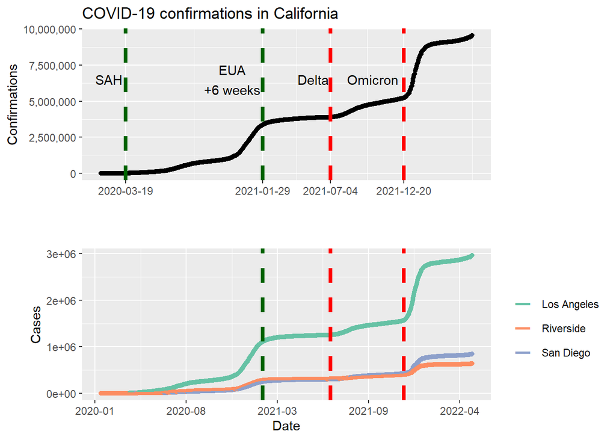

```r
# Prepare data for the plots:

# Get California confirmed data frame
cali_confirmed_df <- na.omit(us_confirmed_df) %>%
                      rename(City = Admin2)%>%
                  filter(Province_State == "California", (Lat & Long_) != 0)

# Get 3 top cities
top3_cities <- cali_confirmed_df %>%
  slice_max(order_by = cali_confirmed_df[,ncol(cali_confirmed_df)], n=3)

# Creates a table with long data for the state or cities input
createLongTable <- function(df, isState=TRUE)
{
  # a variable to store a result dataframe
  result_long_sum <- 0

  if (isState) # check if the dataframe is for a state data
  {
    # summarise all state cases for each day
    result_sum <- df %>% replace(is.na(.), 0) %>%
                summarise(across(12:last_col(),
                            sum, na.rm=T))
    # gather the dates and cases
    result_long_sum <- gather(result_sum,
                          key = Dates,
                          value = Cases)
  } else {
    # gather the dates and cases
    result_long_sum <- gather(df,
                          key = Dates,
                          value = Cases,
                          12:last_col())
  }

  # edit a column with dates
  result_long_sum$Dates <- str_replace(result_long_sum$Dates, "X", "") %>%
                            str_trim(side = "both")

  # format the Dates column as.Date
  # separate the Dates column
  # then put it together
  result_long_sum <- result_long_sum %>%
    separate(Dates, into = c("Month","Day","Year"))%>%
    mutate(Dates = as.Date(ISOdate(year = paste0("20",Year),
                                            month = Month, day = Day)))
}

# Get a long table with dates and cases for California
long_cali_confirmed <- createLongTable(cali_confirmed_df) %>%
                        select(Dates, Cases)

# Get a long table with 3 top cities dates and cases for California
long_top3_cities <- createLongTable(top3_cities, isState=FALSE) %>%
    select(City, Dates, Cases)

# Create vectors with dates, labels, and coordinates for the plot
dates_vec <- as.Date(c("2020-03-19","2021-01-29", "2021-07-04", "2021-12-20"))
x_coord_vec <- as.Date(c("2020-02-10","2020-11-20", "2021-05-25", "2021-10-10"))
y_coord_vec<-rep(6500000,times=4)
labels_vec <- c("SAH","EUA\n+6 weeks","Delta","Omicron")

# Construct the California plot
cali_plot <- ggplot(long_cali_confirmed, aes(Dates, Cases)) +
  geom_point() + labs(title="COVID-19 confirmations in California") +
  labs(x="", y="Confirmations") +
  geom_vline(xintercept = as.numeric(dates_vec[1:2]), linetype=2, color="darkgreen", size=1.5) +
  geom_vline(xintercept = as.numeric(dates_vec[3:4]), linetype=2, color="red", size=1.5) +
    annotate("text",
              x = x_coord_vec,
              y = y_coord_vec,
              label = labels_vec) +
  scale_y_continuous(labels=comma) +
  scale_x_continuous(breaks=dates_vec)

# Construct the top 3 cities plot
top3_cities_plot <- ggplot(long_top3_cities, aes(Dates, Cases, color = City)) +
  geom_point() +
  labs(x="Date") +
  geom_vline(xintercept = as.numeric(dates_vec[2]), linetype=2, color="darkgreen", size=1.5) +
  geom_vline(xintercept = as.numeric(dates_vec[3:4]), linetype=2, color="red", size=1.5) +
  scale_x_date(breaks = "210 days",
  date_labels = "%Y-%m") +
  theme(legend.title = element_blank(),
        legend.key = element_blank()) +
  scale_color_brewer(palette = "Set2") +
  guides(colour = guide_legend(override.aes = list(shape="_",size=7)))

# Display the plots together
plot_grid(cali_plot, top3_cities_plot, nrow = 2, align = "hv", axis = "tblr")
```

### Objective 4

#### Digging Deeper

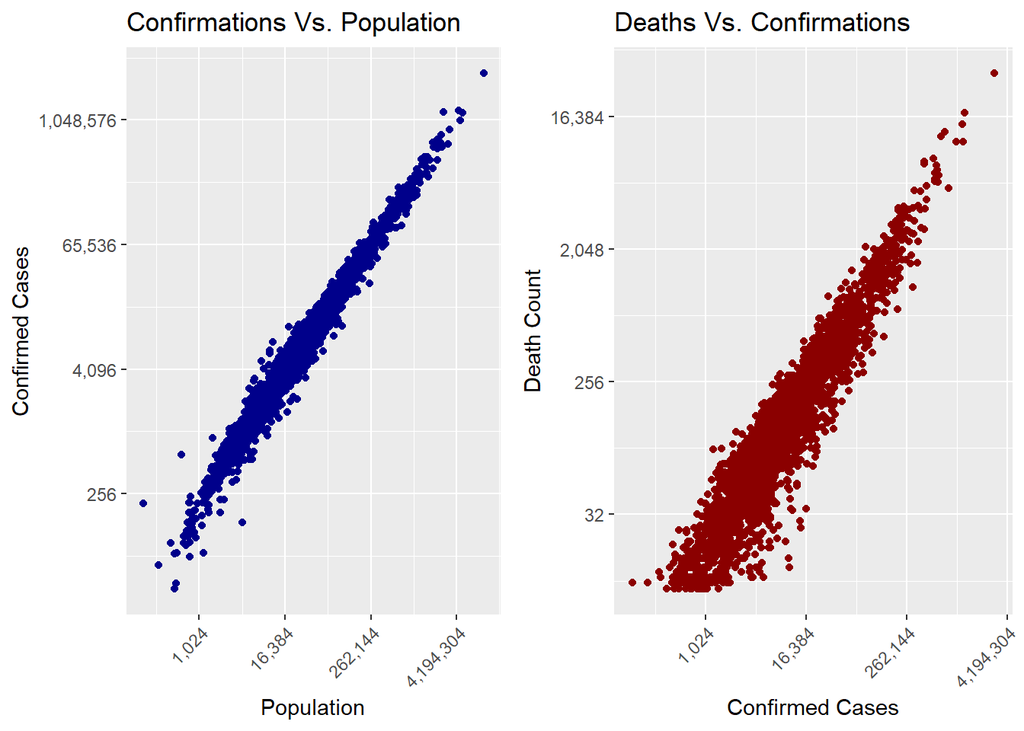

```r
# Select desired variables from US Confirmed and Deaths dataframes,
# as well as the UID variable to enable a clean join
selectedConf <- data.frame("UID"=us_confirmed_df$"UID",
                           "Province_State"=us_confirmed_df$"Province_State",
                           "County"=us_confirmed_df$"Admin2",
                           "Confirmations"=us_confirmed_df[,ncol(us_confirmed_df)])

selectedDeaths <- data.frame("UID"=us_deaths_df$"UID",
                             "Population"=us_deaths_df$"Population",
                             "Deaths"=us_deaths_df[,ncol(us_deaths_df)])

# Join the two selected tables on the UID variable
us_scatterplot1_df <- left_join(selectedConf, selectedDeaths, by = "UID")

# Remove UID and reorder columns
us_scatterplot1_df <- select(us_scatterplot1_df, "Province_State", "County",
                             "Population", "Confirmations", "Deaths")

# Prep data for both scatterplots by removing locations with fewer than 10
# for either Confirmations or Population
us_scatterplot1_df <- filter(us_scatterplot1_df, Confirmations >=  10, Population >= 10)

# Prep data for second scatterplot by also removing locations with fewer than 10 Deaths
us_scatterplot2_df <- filter(us_scatterplot1_df, Deaths >=  10)

# Create scatterplots, using log2 transformation on x and y axis for both plots
us_scatterplot1 <- ggplot(us_scatterplot1_df, aes(Population, Confirmations)) +
  geom_point(color="darkblue") +
  labs(title="Confirmations Vs. Population", x="Population", y="Confirmed Cases") +
  scale_x_continuous(labels = comma, trans="log2") +
  scale_y_continuous(labels = comma, trans="log2") +
  theme(axis.text.x = element_text(angle = 45, hjust = 1))

us_scatterplot2 <- ggplot(us_scatterplot2_df, aes(Confirmations, Deaths)) +
  geom_point(color="darkred") +
  labs(title="Deaths Vs. Confirmations", x="Confirmed Cases", y="Death Count") +
  scale_x_continuous(labels = comma, trans="log2") +
  scale_y_continuous(labels = comma, trans="log2") +
  theme(axis.text.x = element_text(angle = 45, hjust = 1))

# Display scatterplots in grid
plot_grid(us_scatterplot1, us_scatterplot2)
```

### GitHub Log

```bash
git log --pretty=format:"%nSubject: %s%nAuthor: %aN%nDate: %aD%nBody: %b"
```

```
##
## Subject: Change format for the table in objective 2
## Author: Nikolay Skryabin
## Date: Fri, 27 May 2022 18:53:27 -0700
## Body:
##
## Subject: Alternate shades for the table in objective 2
## Author: Nikolay Skryabin
## Date: Fri, 27 May 2022 09:11:51 -0700
## Body:
##
## Subject: Add project2 html file
## Author: Nikolay Skryabin
## Date: Thu, 26 May 2022 11:02:23 -0700
## Body:
##
## Subject: Add minor changes to objective 3 changes
## Author: Nikolay Skryabin
## Date: Wed, 25 May 2022 23:53:39 -0700
## Body:
##
## Subject: Add changes to the html layout, improvements to objectives 1-3. delete dependency calls to the objective 4. move them to the top
## Author: Nikolay Skryabin
## Date: Wed, 25 May 2022 16:00:36 -0700
## Body:
##
## Subject: Added code to create scatterplots for Objective 4
## Author: Jeanine Holscher
## Date: Tue, 24 May 2022 05:11:40 -0700
## Body:
##
## Subject: Add names to the readme file
## Author: Nikolay Skryabin
## Date: Mon, 23 May 2022 14:55:33 -0700
## Body:
##
## Subject: Add code to create the plots in objective 3
## Author: Nikolay Skryabin
## Date: Mon, 23 May 2022 11:42:48 -0700
## Body:
```

[output cut: 20 more lines]

```
##
## Subject: Add project 2 files
## Author: Nikolay Skryabin
## Date: Sat, 21 May 2022 21:21:43 -0700
## Body:
##
## Subject: Update README.md
## Author: NIKOLAY SKRYABIN
## Date: Thu, 19 May 2022 15:38:35 -0700
## Body:
##
## Subject: Initial commit
## Author: NIKOLAY SKRYABIN
## Date: Wed, 18 May 2022 09:23:18 -0700
## Body:
```